# R Notebook

```r
library(tidyverse)
library(janitor)
library(GGally)
library(ggfortify)
library(here)
library(modelr)




here::here()
```

```
[1] "C:/Users/colin/Documents/CodeClan/codeclan_homework_ColinS/week_10/day_3"
```

```r
houses <- read_csv(here("data/kc_house_data.csv"))
houses
```

| id | date | price | bedrooms | bathrooms | sqft_living | sqft_lot | floors | waterfront | view | condition | grade | sqft_above | sqft_basement | yr_built | yr_renovated | zipcode | lat | long | sqft_living15 | sqft_lot15 |
| --- | --- | --- | --- | --- | --- | --- | --- | --- | --- | --- | --- | --- | --- | --- | --- | --- | --- | --- | --- | --- |
| 7129300520 | 2014-10-13 | 221900 | 3 | 1.00 | 1180 | 5650 | 1.0 | 0 | 0 | 3 | 7 | 1180 | 0 | 1955 | 0 | 98178 | 47.5112 | -122.257 | 1340 | 5650 |
| 6414100192 | 2014-12-09 | 538000 | 3 | 2.25 | 2570 | 7242 | 2.0 | 0 | 0 | 3 | 7 | 2170 | 400 | 1951 | 1991 | 98125 | 47.7210 | -122.319 | 1690 | 7639 |
| 5631500400 | 2015-02-25 | 180000 | 2 | 1.00 | 770 | 10000 | 1.0 | 0 | 0 | 3 | 6 | 770 | 0 | 1933 | 0 | 98028 | 47.7379 | -122.233 | 2720 | 8062 |
| 2487200875 | 2014-12-09 | 604000 | 4 | 3.00 | 1960 | 5000 | 1.0 | 0 | 0 | 5 | 7 | 1050 | 910 | 1965 | 0 | 98136 | 47.5208 | -122.393 | 1360 | 5000 |
| 1954400510 | 2015-02-18 | 510000 | 3 | 2.00 | 1680 | 8080 | 1.0 | 0 | 0 | 3 | 8 | 1680 | 0 | 1987 | 0 | 98074 | 47.6168 | -122.045 | 1800 | 7503 |
| 7237550310 | 2014-05-12 | 1225000 | 4 | 4.50 | 5420 | 101930 | 1.0 | 0 | 0 | 3 | 11 | 3890 | 1530 | 2001 | 0 | 98053 | 47.6561 | -122.005 | 4760 | 101930 |
| 1321400060 | 2014-06-27 | 257500 | 3 | 2.25 | 1715 | 6819 | 2.0 | 0 | 0 | 3 | 7 | 1715 | 0 | 1995 | 0 | 98003 | 47.3097 | -122.327 | 2238 | 6819 |
| 2008000270 | 2015-01-15 | 291850 | 3 | 1.50 | 1060 | 9711 | 1.0 | 0 | 0 | 3 | 7 | 1060 | 0 | 1963 | 0 | 98198 | 47.4095 | -122.315 | 1650 | 9711 |
| 2414600126 | 2015-04-15 | 229500 | 3 | 1.00 | 1780 | 7470 | 1.0 | 0 | 0 | 3 | 7 | 1050 | 730 | 1960 | 0 | 98146 | 47.5123 | -122.337 | 1780 | 8113 |
| 3793500160 | 2015-03-12 | 323000 | 3 | 2.50 | 1890 | 6560 | 2.0 | 0 | 0 | 3 | 7 | 1890 | 0 | 2003 | 0 | 98038 | 47.3684 | -122.031 | 2390 | 7570 |

[output cut: 990 more lines]

# Question 1

Tidy up the data ready for regression

```r
head(houses)
```

| id | date | price | bedrooms | bathrooms | sqft_living | sqft_lot | floors | waterfront | view | condition | grade | sqft_above | sqft_basement | yr_built | yr_renovated | zipcode | lat | long | sqft_living15 | sqft_lot15 |
| --- | --- | --- | --- | --- | --- | --- | --- | --- | --- | --- | --- | --- | --- | --- | --- | --- | --- | --- | --- | --- |
| 7129300520 | 2014-10-13 | 221900 | 3 | 1.00 | 1180 | 5650 | 1 | 0 | 0 | 3 | 7 | 1180 | 0 | 1955 | 0 | 98178 | 47.5112 | -122.257 | 1340 | 5650 |
| 6414100192 | 2014-12-09 | 538000 | 3 | 2.25 | 2570 | 7242 | 2 | 0 | 0 | 3 | 7 | 2170 | 400 | 1951 | 1991 | 98125 | 47.7210 | -122.319 | 1690 | 7639 |
| 5631500400 | 2015-02-25 | 180000 | 2 | 1.00 | 770 | 10000 | 1 | 0 | 0 | 3 | 6 | 770 | 0 | 1933 | 0 | 98028 | 47.7379 | -122.233 | 2720 | 8062 |
| 2487200875 | 2014-12-09 | 604000 | 4 | 3.00 | 1960 | 5000 | 1 | 0 | 0 | 5 | 7 | 1050 | 910 | 1965 | 0 | 98136 | 47.5208 | -122.393 | 1360 | 5000 |
| 1954400510 | 2015-02-18 | 510000 | 3 | 2.00 | 1680 | 8080 | 1 | 0 | 0 | 3 | 8 | 1680 | 0 | 1987 | 0 | 98074 | 47.6168 | -122.045 | 1800 | 7503 |
| 7237550310 | 2014-05-12 | 1225000 | 4 | 4.50 | 5420 | 101930 | 1 | 0 | 0 | 3 | 11 | 3890 | 1530 | 2001 | 0 | 98053 | 47.6561 | -122.005 | 4760 | 101930 |

```r
houses_trim <- houses %>%
  select(-c(id, date, sqft_lot, sqft_living15, sqft_lot15, zipcode)) %>%
  mutate(waterfront = as.logical(waterfront),
         yr_renovated = if_else(yr_renovated == 0, FALSE, TRUE))
```

`condition` and `grade` are categorical ordinal data, so should probably be transformed.

```r
houses_trim <- houses_trim %>%
  mutate(grade = case_when(
    grade <= 3 ~ "poor",
    grade > 3 & grade <= 5 ~ "below average",
    grade > 5 & grade <= 8 ~ "average",
    grade > 8 & grade <= 10 ~ "above average",
    grade > 10  ~ "excellent")) %>%
  mutate(condition = case_when(
    condition == 1 ~ "poor",
    condition == 2 ~ "below average",
    condition == 3 ~ "average",
    condition == 4 ~ "above average",
    condition == 5  ~ "excellent"))
```

# Question 2

Check for aliased variables using the alias() function (this takes in a formula object and a data set).

```r
alias(lm(price ~ ., data = houses_trim))
```

```
Model :
price ~ bedrooms + bathrooms + sqft_living + floors + waterfront +
    view + condition + grade + sqft_above + sqft_basement + yr_built +
    yr_renovated + lat + long

Complete :
              (Intercept) bedrooms bathrooms sqft_living floors waterfrontTRUE view
sqft_basement  0           0        0         1           0      0              0
              conditionaverage conditionbelow average conditionexcellent conditionpoor
sqft_basement  0                0                      0                  0
              gradeaverage gradebelow average gradeexcellent gradepoor sqft_above yr_built
sqft_basement  0            0                  0              0        -1          0
              yr_renovatedTRUE lat long
sqft_basement  0                0   0
```

The `alias()` function shows that `sqft_basement` can be calculated from `sqft_living` and `not sqft_above`. So `sqft_basement` and `sqft_above`could be dropped from the data set.

```r
houses_trim <- houses_trim %>%
  select(-sqft_basement, -sqft_above)
```

# Question 3

Systematically build a regression model containing up to four main effects (remember, a main effect is just a single predictor with coefficient), testing the regression diagnostics as you go.

[output not shown]

[output cut: 26 more lines]

[output not shown]

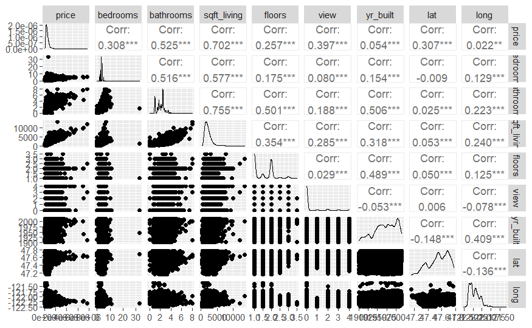

```r
houses_tidy_numeric <- houses_trim %>%
  select_if(is.numeric)

houses_tidy_nonnumeric <- houses_trim %>%
  select_if(function(x) !is.numeric(x))

houses_tidy_nonnumeric$price <- houses_trim$price

ggpairs(houses_tidy_numeric)
```

[output not shown]

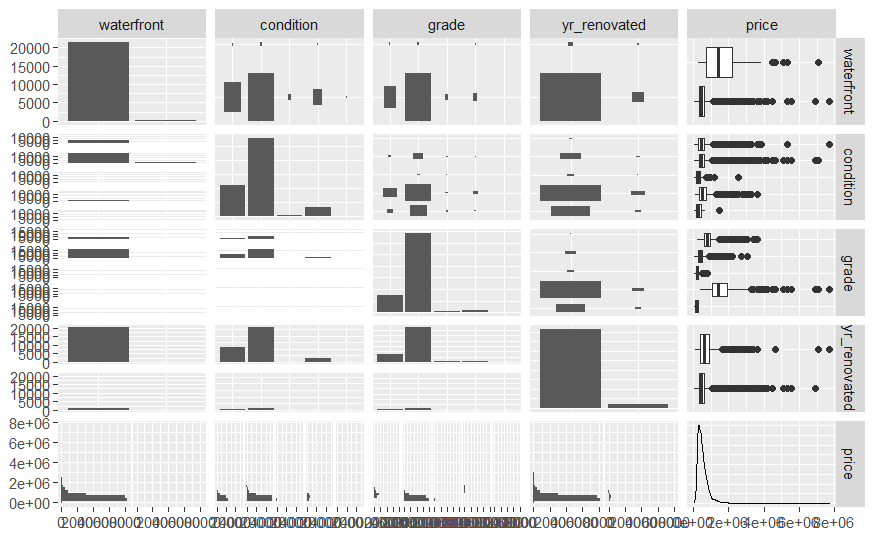

```r
ggpairs(houses_tidy_nonnumeric)
```

At first glance it looks like there is a strong correlation between;

- price and sqft_living
- price and bathrooms

It also looks like `waterfront` has a strong effect on price.

## mod1a: price ~ sqft_living

```r
mod1a <- lm(price ~ sqft_living, data = houses_trim)
mod1a
```

```
Call:
lm(formula = price ~ sqft_living, data = houses_trim)

Coefficients:
(Intercept)  sqft_living
   -43580.7        280.6
```

So in isolation,
$$price = -43580.7 + 280.6 * sqft\_living$$

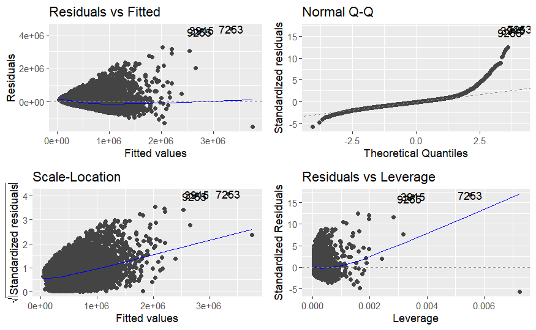

```r
autoplot(mod1a)
```

This data does not look good. None of the plots look acceptable, so sqft_living can’t be used as a predictor.

## mod1b: price ~ bathrooms

```r
mod1b <- lm(price ~ bathrooms, data = houses_trim)
mod1b
```

```
Call:
lm(formula = price ~ bathrooms, data = houses_trim)

Coefficients:
(Intercept)    bathrooms
      10708       250327
```

So in isolation,
$$price = 10708 + 250327 * bathrooms$$

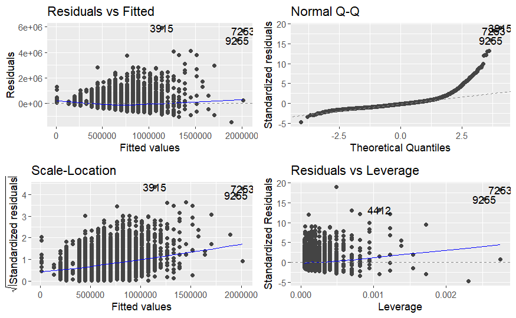

```r
autoplot(mod1b)
```

The diagnostics for bathrooms also look unacceptable!

## mod1c: price ~ waterfront

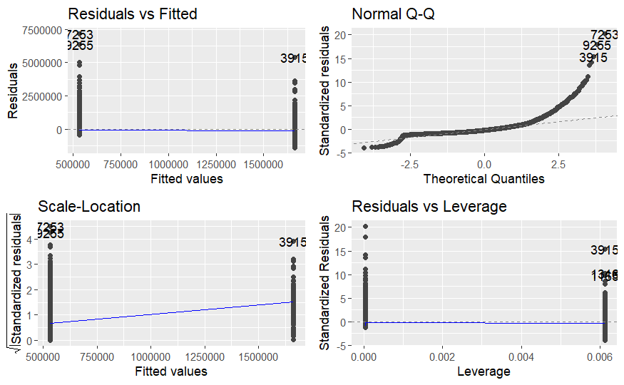

```r
mod1c <- lm(price ~ waterfront, data = houses_trim)
autoplot(mod1c)
```

…the Q-Q plot looks very non-linear!

I don’t know where to go from here - I’ve tried four different predictors (I deleted one much earlier!) and they all look unusable in the diagnostic plots, which suggests to me that the basic assumptions of normality for linear regression are not being met.

I suspect that I’m doing something fundamentally wrong, maybe at the data transformation stage, but I don’t know what?